[figure not shown]

#### MASEF, University Paris-Dauphine 2021: Bryan Delamour

# Test of the Hybrid Scheme implementation

```python
import numpy as np
import matplotlib.pyplot as plt
from ipynb.fs.full.rbergomi_MC import *
from ipynb.fs.full.utils import *
from ipynb.fs.full.HybridScheme import *
from time import time
import scipy as sc
from statsmodels.tsa.stattools import kpss
import pandas as pd
```

## Fractional Brownian motion and asset paths

#### Here we generate a few paths with different Hurst parameters to illustrate

### Hurst index

The Hurst index H is a real number in (0, 1), it describes the roughness of the resultant motion.

The value of $H$ determines what kind of process the fBm is:

if $H=1 / 2$ then the process is in fact a Brownian motion or Wiener process.

if $H>1 / 2$ then the increments of the process are positively correlated.

if $H<1 / 2$ then the increments of the process are negatively correlated.

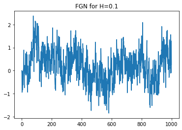

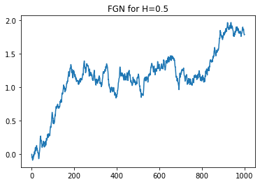

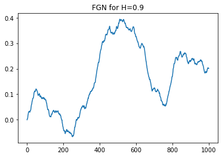

```python
H_=[0.1,0.5,0.9]

for h in H_ :
    test = rBergomi_h( paths = 1, N = 1000, T = 1.00, H = h)
    W = test.dW() # our Brownian
    W_h = test.W_h(W) # our Fractionnal Brownian Motion
    plt.plot(W_h[0,:])
    plt.title( "FGN for H=" + str(h) )
    plt.show()
```

### Necessary and sufficient condition for the fBm

##### Reference: Quality estimation of synthesis methods of fractional Brownian motion, Jennane, Jacquet (1996)

a) Normality of the process

b) Increments stationarity

$$ B_{H}(t)-B_{H}(s) \sim B_{H}(t-s) $$

c) Self-similarity $$ B_{H}(a t) \sim|a|^{H} B_{H}(t) $$

### a) Normality of the process

We will perform a Shapiro-Wilk test

$H_0$ = The sample is normally distributed

```python
H=0.1
paths=5000
N_Disc = 1000

test = rBergomi_h( paths = 10000, N = 1000, T = 1.00, H = 0.1)
W = test.dW() # our Brownian
W_h = test.W_h(W) # our Fractionnal Brownian Motion

p_values = np.zeros(N_Disc)
fbm = W_h
for t in range(1,N_Disc):
    TestNormal = sc.stats.shapiro(fbm[:,t])
    p_values[t] = TestNormal.pvalue

print ("Hurst index", H)
print("nb of p_values < 0.05",sum((p_values<0.05)*1) )
```

```
Hurst index 0.1
nb of p_values < 0.05 37
```

### Distribution illustration

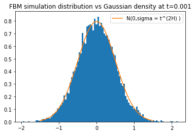

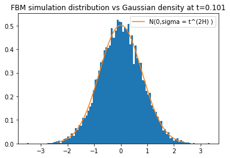

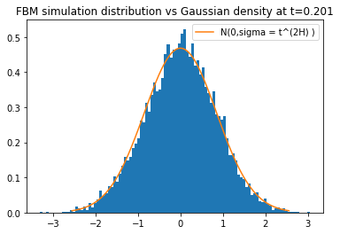

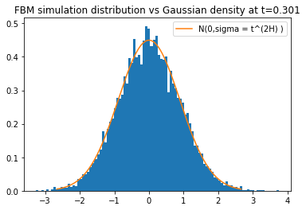

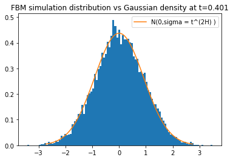

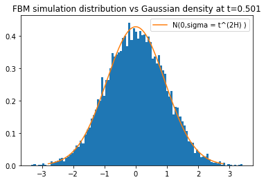

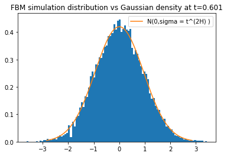

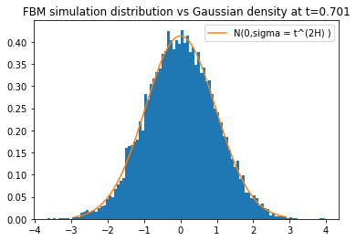

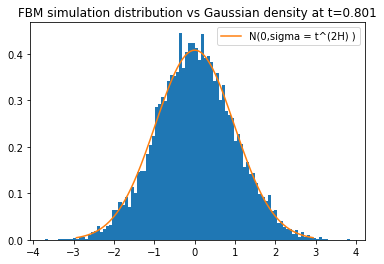

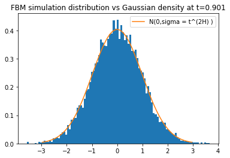

```python
H=0.1
paths=10000
N_Disc=1000
test = rBergomi_h( paths = 10000, N = 1000, T = 1.00, H = 0.1)
W = test.dW() # our Brownian
W_h = test.W_h(W) # our Fractionnal Brownian Motion
fbm = W_h
t_ = np.arange(1,1000,100)

for t in t_:
    plt.hist(fbm[:,t],bins=100,density=True)
    ti = t/1000
    sigma = np.sqrt(ti**(2*H))
    x = np.linspace( -3*sigma, 3*sigma, 10000)
    y = sc.stats.norm.pdf(x, 0, sigma)
    plt.title("FBM simulation distribution vs Gaussian density at t="+str(ti))
    plt.plot(x, y, label="N(0,sigma = t^(2H) )")
    plt.legend(loc="best")
    plt.show()
```

### b) Increments stationarity

$$ B_{H}(t)-B_{H}(s) \sim B_{H}(t-s) $$

#### Mean Stationarity

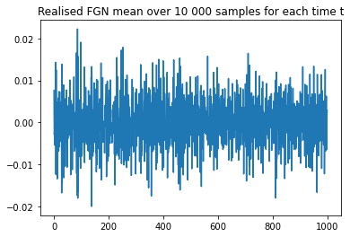

```python
H=0.1
paths=10000
test = rBergomi_h( paths = 10000, N = 1000, T = 1.00, H = 0.1)
W = test.dW() # our Brownian
W_h = test.W_h(W) # our Fractionnal Brownian Motion
fgn = W_h[:, 1:] - W_h[:, :-1]

mean = np.mean(fgn,axis=0)
plt.title( "Realised FGN mean over 10 000 samples for each time t")
plt.plot(mean)
plt.show()
```

#### KPSS Test

$H_0$ = The increment process is stationary

```python
# KPSS test

def kpss_test(timeseries):
    print ('Results of KPSS Test:')
    kpsstest = kpss(timeseries, regression='c', nlags="auto")
    kpss_output = pd.Series(kpsstest[0:3], index=['Test Statistic','p-value','Lags Used'])
    for key,value in kpsstest[3].items():
        kpss_output['Critical Value (%s)'%key] = value
    print (kpss_output)

kpss_test(mean)
```

```
Results of KPSS Test:
Test Statistic            0.048179
p-value                   0.100000
Lags Used                69.000000
Critical Value (10%)      0.347000
Critical Value (5%)       0.463000
Critical Value (2.5%)     0.574000
Critical Value (1%)       0.739000
dtype: float64
```